# Week 5 Seminar: Generalization

Kash

11/01/2022

```r
library(tidyverse)
library(broom)
library(glmnet)
```

Generalization: - Everytime we use a probabilistic model, we have some foundation assumptions - One of them is that there exists a sample space (set of all possible outcomes) and we know it - Fail to generalize in some sense because something about the design of the experiment drew the boundary in a certain way that people weren’t aware of. And when they went to check the conclusion, the boundry was different in some way. - Eg. some kind of finding that people first observe in a lab but then when they go outside in the world and check if the same finding is truw, it doesn’t hold. - Mice experiment explained in class

# High-dimensional regression

##Generate some data from a high-dimensional model (increase p below)

```r
#set.seed(1)
n = 100 # number of observations
p = 20 # number of predictor variables
X <- matrix(rnorm(n*p), nrow = n) # here, its iid normal. You can change from random number generator to uniform - runif(n*p)

# Almost all methods work better with normally generated things. So, if your methods seems to work well on this and doesn't work too well on real datasets, one of the reasons must be that the real dataset isn't normal.

beta <- rpois(p, lambda = 1) # coefficient vector generated from poisson random variable
# beta <- c(-1, 1, rep(0,p-2))

y <- X %*% beta + rnorm(n) # generate data using a known model (here, linear)
# rnorm(n) is noise coded as a normal random variable
```

```r
beta #coefficient values
```

```
##  [1] 1 1 2 1 0 1 0 4 0 1 2 0 3 0 1 0 2 2 0 1
```

## Ridge Regression with glmnet

We will study ridge regression in more detail soon. For now you only need to know it’s a method we can use for fitting high-dimensional regression models.

*ie. you can use it to fit regression models even if you have more predictor variables than you have observations.* - Eg. in least squares regression, you have to invert a matrix and if you don’t have more observations than predictors, it is not invertible.

It also involves a tuning parameter called “*lambda*,” and *larger values of lambda result in simpler fitted models*. (We’ll learn about how they are simpler soon when we study penalized regression)

Use the `glmnet` package to fit a ridge regression model on the same data as in the previous part. Hint: read about the `alpha` input to the `glmnet` function in the documentation.

```r
model_ridge <- glmnet(X, y,
                      intercept = FALSE,
                      alpha = 0, # defaul alpha=1 and it does lasso regre.
                      lambda = 10^(-3:3) # range of value for lambda (tuning parameter) and we get a sequence of ridge regression models that are fit at different values of lambda
                      )
```

## What does plotting the model object show?

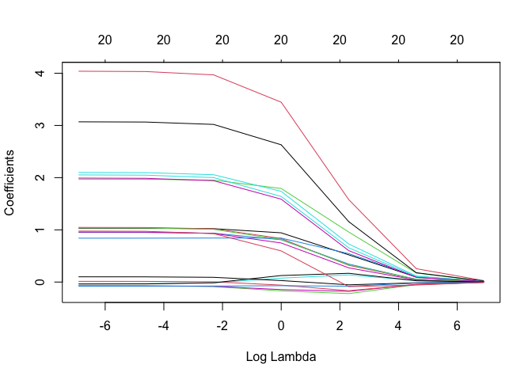

```r
# or autoplot(model_ridge, xvar = "lambda")
plot(model_ridge, xvar = "lambda")
```

The lambda (tuning parameter) is also called a penalty parameter becasue it changes the loss function. The loss function has a least squares part and it has a penalty on the size of your coefficients. So, when lambda is very large, we are penalizing the coefficients very heavily. So, to minimize the loss function, we want the coefficients to be very small.

Towards the left, the coefficients are penalized less and instead of setting those coefficients to be close to 0, it allows them to be usd to minimize the least squares part of the loss function.

Hence, towards the right, the penalty part of the loss func is dominant and the optimum is trying to minimize the penalty part. And towards left, when we weigh the penalty part less, the least squares part becomes dominant and the coefficients are trying to minimize the prediction error instead of minimizing penalty.

*observation 2:*

Remember the true model that we generated? and the coefficient values that we had (beta)? The lines here are at those 0,1,2,3 values of beta so this model is giving me estimates close to the true values if I don’t penalize them too much.

- Estimation - how well are we estimating true parameters?
- Prediction - how well are we predicting y?

## Estimation Error

Compute the mean-squared error of the coefficient estimates at different values of lambda

Estimation error will be different for models with different lambdas.

```r
# Estimation error for lambda=1

lambda <- 10^0 #change lambda = 10^1,10^2,etc
beta_hat <- coef(model_ridge, s = lambda)[-1] #leave out intercept
beta_hat # gives 20 values since we have 20 predictior variables
```

```
##  [1]  0.94265442  0.83414822  1.79182077  0.80930998  0.07546620  0.74772866
##  [7]  0.02820925  3.44501480 -0.16896771  0.84155254  1.63942979 -0.14430182
## [13]  2.62913139 -0.05912432  0.81484836 -0.07008178  1.73700376  1.58730583
## [19]  0.12453891  0.59605450
```

```r
# Mean squared error
mean((beta_hat - beta)^2)
```

```
## [1] 0.06457618
```

There are various ways of measuring estimation error when you have a vector of parameters: 1. Mean squared error across the vector 2. Sum of squared errors

Notice, as you change lambda, the mean-squared error is large if lambda is too large (coz all the coefficients have been penalized to be very close to 0). So, the only time we would have a good mean square error if our penalty/tuning parameter is very large is if the true parameters are also close to 0.

## Prediction Error

Compute predictions using the estimated coefficients and the mean-squared prediction error

```r
# Use predict() function
mean((predict(model_ridge, newx = X, s = lambda) - y)^2) # or s = 10*lambda or lambda/10 to see error when lambda is larger or smaller
```

```
## [1] 1.69275
```

```r
# or using mean squared prediction error
lambda <- 10^0
y_hat <- X %*% beta_hat # if you change lambda above to a multiple of it, then to get same result, recompute beta_hat because we computed beta_hat above with lambda
mean((y - y_hat)^2)
```

```
## [1] 1.69275
```

## Discussion

*Q.1 In a real data analysis (rather than simulation), which of the above things could we not compute, and why?* - Assumptions were true, by construction, for our simulations - We can still check prediction error (we have our predicted value of y and we have true value of y from our dataset) but we cannot check estimation error (parameters are mathematical constructions - no way we can actually observe it) -Caveat: when your true parameter is defined as some population quantity and you have full consensus on it - Caveat: when your true parameter is like a constant of nature like speed of light

This is why we are so focused on predictions in ML and AI

*Q.2 How do the results change depending on lambda?*

*Q.3 How do the results change depending on dimension? (e.g. if p > n)* Change the code above and check.

LOW DIMENSION:

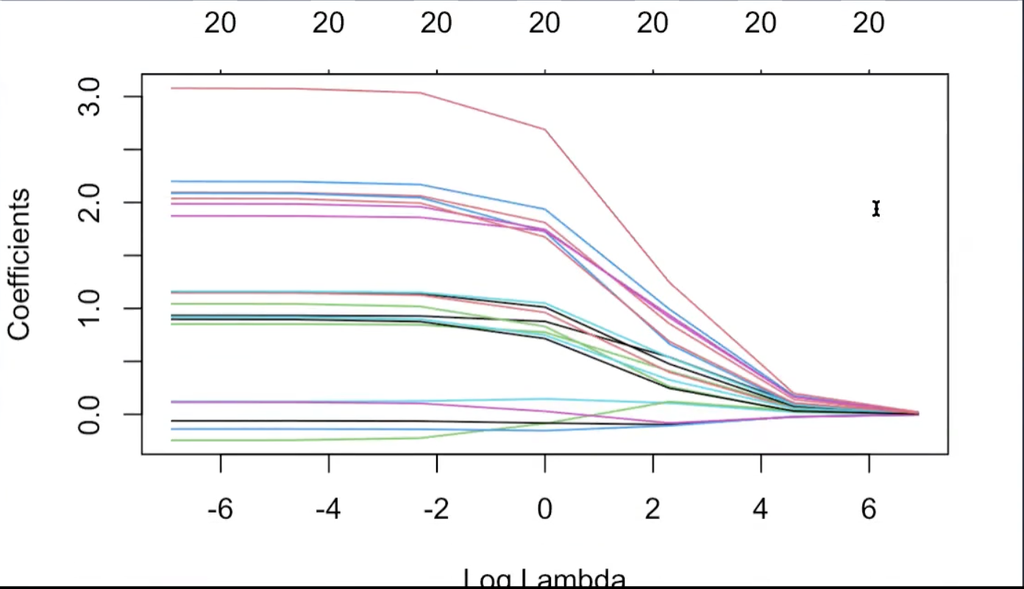

1. See that the lines are grouped at 0,1,2,3 2. Lowest estimation/prediction error when lambda was smaller

HIGH DIMENSION:

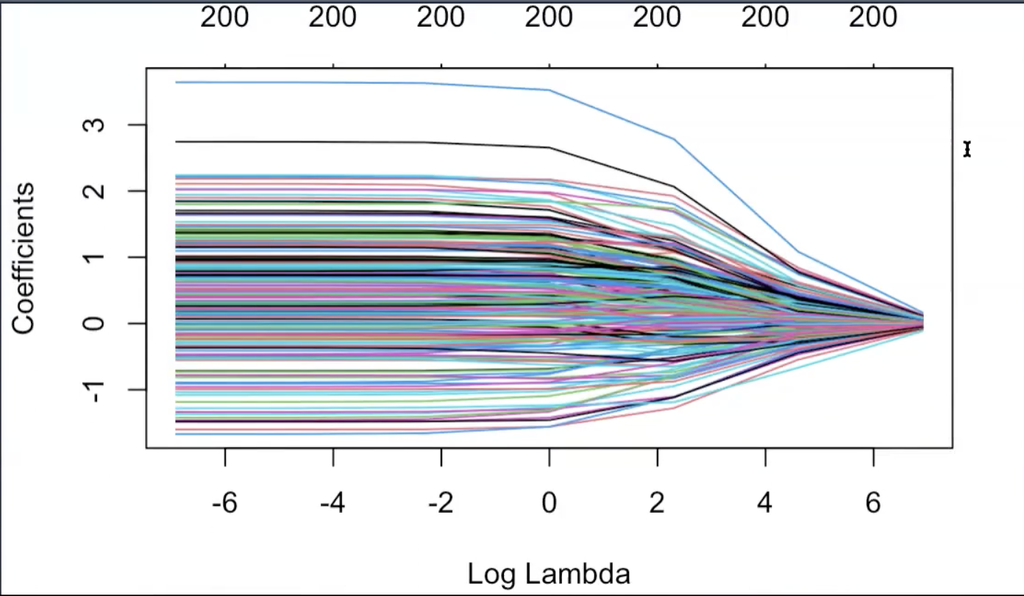

1. I no longer know if these results are good. Instead of having 20 lines which are grouped at 0,1,2,3, here I have 200 lines spread all over. 2. Not too sure about the relation between lambda and estimation/prediction errors here… seem to have plateaued

# “Overfitting to Variance” and ID Generalization

## Generate a new sample from the same distribution (which things stay fixed?)

```r
N <- 1000 # can set any sample size
# In-Distribution (ie. use same distribution to generate new data)
X_ID <- matrix(rnorm(N*p), nrow = N)
y_ID <- X_ID %*% beta + rnorm(N)
```

NOTE: we don’t redefine `beta` here if we are interested in studying the same probability distribution model. Ususally, in high dimensional regression here, we are interested in learning the coefficients. But if the coefficients are the parameters we actually wanna study, then it means that we want to keep the probability distribution fixed, the in-distribution generalization I want for that one probability distribution should be the one that has the same coefficients. Hence, we keep beta fixed.

## Calculate the predicted error on this new sample at different values of lambda

We are keeping the same model as before but predicting using the new observations

```r
mean((predict(model_ridge, newx = X_ID, s = lambda) - y_ID)^2)
```

```
## [1] 2.462595
```

## Discussion

Maybe, try changing lambda and p too.

*Q.2 How do these compare if we increase the original (training) sample size?* Sample size of new data doesn’t really change anything. But larger sample size on original training data, it reduces variability.

# “Overfitting to bias” and OOD generalisation

There are many ways to change the distribution for a new sample

- Change beta (maybe add a small amount of noise)
- Change the CEF some other way (e.g. add a non-linear term)
- Change the distribution of X and/or the errors

Pick one of these and test OOD generalisation (prediction error on new, different sample)

```r
X_OOD <- matrix(rnorm(n*p), nrow = n) # predictor matrix

beta_OOD <- beta + rnorm(p, sd = .1) # coefficients are only slightly different from the original coefficients

y_OOD <- X_OOD %*% beta_OOD + rnorm(n) # predicted variable
```

Prediction Error

```r
mean((predict(model_ridge, newx = X_OOD, s = lambda) - y_OOD)^2)
```

```
## [1] 3.029935
```

```r
y_OOD_hat <- predict(model_ridge, newx = X_OOD, s = 10*lambda)
mean((y_OOD - y_OOD_hat)^2)
```

```
## [1] 22.38227
```

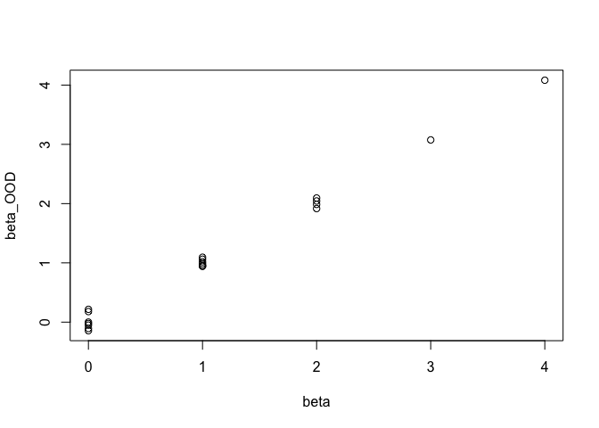

```r
plot(beta,beta_OOD)
```

## Discussion

Real world data does not follow probability distributions. So, in-distribution generalization is a fiction. So, we would need to do something more like OOD-generalization.

The only time that you can use in-distribution generalization is if you train your model on some random subset of your dataset. Because then, your training data is actually a random subset of the data that you are going to gneralize to. But it is kind of going backwards… - This is actually a strategy we use to avoid over-fitting. All our ML methods like ridge regression, high level regression, etc fit complex models and avoid overfitting using this method.

*Q.1 How do these compare if we increase the original (training) sample size?*

*Q.2 Similarities and differences between in-distribution and out-distribution generalisations?*

- for ID, larger sample meant less variablity in our fitted model. So we can improve our ID generalization by training model on larger sample size

But is this true for OOD generalization?

# Comparison with gradient descent

Copy/paste your gradient descent (or stochastic version) code for ordinary linear regression here. Does it converge? If so, to what? Check distance (MSE) from the true beta and from the ridge estimate of beta (at different values of lambda, or a very small lambda close to zero)

(Also consider generating data with p larger than n, so the least squares estimator is undefined)

```r
# Gradient of the loss function
least_squares_gradient <- function(x, y, beta) {
  -2 * t(x) %*% (y - x %*% beta) #+ 2 * beta
}

# Loss function
least_squares_loss <- function(x, y, beta) {
  sum((y - x %*% beta)^2)
}

beta_prev2 <- rep(0, p) # or random start point
grad_prev2 <- least_squares_gradient(X, y, beta_prev2)
beta_prev1 <- beta_prev2 + 0.1 * grad_prev2 / sqrt(sum(grad_prev2^2))
grad_prev1 <- least_squares_gradient(X, y, beta_prev1)
previous_loss <- least_squares_loss(X, y, beta_prev2)
next_loss <- least_squares_loss(X, y, beta_prev1)
steps <- 1

while (abs(previous_loss - next_loss) > 0.001) {
  grad_diff <- grad_prev1 - grad_prev2
  step_BB <- sum((beta_prev1 - beta_prev2) * grad_diff) / sum(grad_diff^2)

  beta_prev2 <- beta_prev1
  beta_prev1 <- beta_prev1 - step_BB * grad_prev1

  grad_prev2 <- grad_prev1
  grad_prev1 <- least_squares_gradient(X, y, beta_prev1)

  previous_loss <- next_loss
  next_loss <- least_squares_loss(X, y, beta_prev1)

  #if (round(steps/10) == steps/10)
  print(previous_loss)
  steps <- steps + 1
}
```

```
## [1] 4858.07
## [1] 804.4931
## [1] 320.9744
## [1] 157.6022
## [1] 93.53142
## [1] 83.95315
## [1] 78.60555
## [1] 77.60665
## [1] 77.18687
## [1] 76.59835
## [1] 76.59713
```

```r
beta_final <- beta_prev1
```

```r
mean((beta_final - beta)^2)
```

```
## [1] 0.004251426
```

```r
beta_zero <- coef(model_ridge, s = 10^(-3))[-1]
mean((beta_final - beta_zero)^2)
```

```
## [1] 4.942559e-07
```